# Experimental Sociology - Week 04

- Show All Code
- Hide All Code
- View Source

Agent-based Models: Basics

Published

2025-03-21

> ,,§1. Soziologie [..] soll heißen: eine Wissenschaft, welche soziales Handeln deutend verstehen und dadurch in seinem Ablauf und seinen Wirkungen ursächlich erklären will.” (Weber 1972 : 1)

> ,,Man kann spekulieren, dass sich Weber heute der Computersimulationen bedienen und ‘deutend verstehen’ in ‘simulierend verstehen’ abändern würde.” (Lindenberg 1971: 100)

# 🤖 Agent-based Modelling

Welcome to the fascinating world of agent-based modeling (ABM)! In this chapter, we’ll lay the groundwork for understanding how to design, implement, and analyze simple agent-based models. No advanced programming background required—we’ll take it step by step. For this we will use a classic example: the **Schelling segregation model** (Schelling 1971).

## 🎯 Learning Goals

By the end of this chapter, you will be able to:

- Understand the purpose and structure of the **ODD protocol** for describing agent-based models.
- Initialize a model in a **reproducible** and transparent way.
- Simulate **time steps** where agents interact with each other and the environment.
- Extract and analyze different types of **data outputs** from the model.
- Apply basic **coding best practices** in R to keep your model clean and modular.

## 🛠️ Basic Skills

You don’t need a background in informatics or computer science—but there are a few coding habits that will make your life easier and your models better.

Here are some simple principles:

- **Write clean and readable code.** We’ll follow the [tidyverse style guide](https://style.tidyverse.org/) to keep things consistent and understandable.
- **Use functions** to separate logic into reusable blocks. Place them in well-named R scripts like `functions_init.R`, `functions_run.R`, etc.
- **Choose meaningful variable names.** Avoid vague names like `x`, `temp1`, or `foo`.
- **Comment your code** where needed, especially when logic isn’t obvious at first glance.
- **Test your model regularly.** Small bugs are easier to fix than big ones!

# 🧱 Basic Simulation

In agent-based modeling, we create a **world** where **agents** live, move, and interact over time. These agents follow simple rules, but when they act together, interesting and often unexpected patterns can emerge.

But how do we create such a world? We do this through a **model**—think of it as a kind of **cooking recipe**. It tells us exactly how to create the same type of world, with the same kind of agents and rules, again and again. This is essential for **reproducibility**, which is a fancy word for “being able to do it the same way every time.”

When we simulate a model from start to finish, we call that a **sequence**.[^1] Each sequence produces a unique version of the world, based on the same underlying recipe, but possibly with different outcomes (depending on random elements, initial conditions, etc.).

Since these simulated worlds can get large and complex, they can also eat up a lot of computer memory. But here’s the good news: we’re usually not interested in everything about the world. Instead, we care about specific aspects of it—like how many agents moved, how segregated the population became, or how many interactions occurred.

That means we treat the world as a kind of **data generator**. We build it, run it, and then extract the information we care about—usually as numbers, summaries, or visualizations.

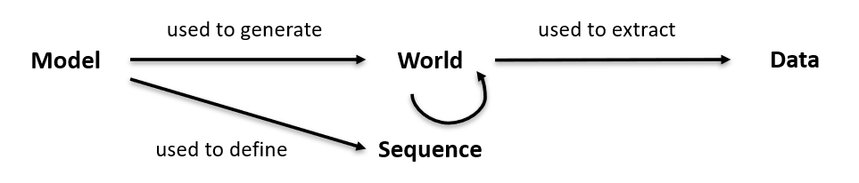

This is the general workflow that can be seen in Figure 1 we’ll follow throughout in the next section:

- **Specify the model** – define the agents, rules, and world setup.
- **Generate the world** – use the model to simulate a run.
- **Extract data** – collect statistics or patterns from the simulation.

**Planning ahead**

Let’s start by **planning our model** before writing any code. We’ll use a classic example: the **Schelling segregation model** (Schelling 1971). In this model, agents of different types move around a grid based on how comfortable they feel with their neighbors.

Here are a few conceptual questions we need to answer first:

- What does the **world** look like? A grid? What size?
- What **types of agents** will we simulate? How many of each?
- What **rules** do the agents follow? (e.g., move if they’re unhappy with their neighbors?)
- What **data** do we want to collect? (e.g., segregation levels over time?)

This process of **thinking before coding** helps us stay organized and prevents frustration later. It’s always worth sketching out your logic on (digital) paper first.

## Specifying the Model

Let’s take our first step and **define the model parameters**. To keep things simple, we’ll start with just a few core components that describe the initial state of our world.

- `world_size` sets the side length of our $m \times m$ grid. For example, if `world_size = 5`, we’ll create a 5×5 world.
- `world_empty` defines the **proportion of vertices that are unoccupied** (i.e. empty flats).
- `pop_shares` is a vector that does two things:
  1. It determines **how many types of agents** we have, by the number of values in the vector (in our case, two).
  2. It specifies their **relative shares** among the non-empty vertices.  
     This flexible format allows us to easily extend the model later to three or more populations.

```r
world_size   = 10          # the grid will be 10x10
world_empty  = 0.2         # 20% of the vertices are empty
pop_shares   = c(0.5, 0.5) # two groups with equal sizes
```

To ensure **reproducibility**, we also define a `seed`. This guarantees that the same world is generated each time we run the model—crucial for debugging and comparing sequences.

```r
seed         = 42          # the initial seed for creating the same world over and over
```

Rather than scattering these settings throughout your code, it’s a good idea to **bundle everything into a single list**, which we’ll call `model`. This approach has two main advantages:

1. It makes your code **cleaner and easier to extend** later (see next sections).
2. It allows you to **switch between model setups** more easily (e.g., comparing different scenarios or parameter sets).

Here’s what that looks like:

```r
model <- list(
  # --- world generation ---
  world_size   = 10,          # creates a world of 10x10 vertices
  world_empty  = 0.2,         # 20% of the grid is empty
  pop_shares   = c(0.5, 0.5), # equal population sizes for two groups
  seed         = 42           # the initial seed for creating the same world over and over
)
```

## Generate the World

Now we’ll write a function to **initialize the world** using the **`igraph`** package. Each vertex in the graph represents a flat, and is assigned a `type`attribute:

- 0 if it is a empty flat,
- $k$ if it is occupied by an agent of group $k$.

We will use a **regular 2D lattice**, where each vertex is connected to its four orthogonal neighbors (north, east, south, west). This is a simplification of the original Schelling model (which uses eight neighbors), but `igraph` doesn’t support that structure directly. In addition, we will work with the `tidyverse` package for good measure.

Below is our `init_world()` function:

```r
library(igraph)
library(tidyverse)

init_world <- function(model) {
  # For reproduceability we set a seed
  set.seed(model$seed)

  m <- model$world_size
  n <- m * m

  # 1) Generate the world

  world <- make_lattice(
    dimvector = c(m, m),
    nei        = 1
  )

  # Calc how many vertices will be populated by agents or stay empty
  pop_counts  <- round((1 - model$world_empty) * n * model$pop_shares)
  empty_count <- n - sum(pop_counts)

  # Build the vector of vertice‐types: 0 = empty, 1..k = group labels
  vertice_pool <- c(
    rep(0, empty_count),
    unlist(lapply(seq_along(pop_counts),
                  function(i) rep(i, pop_counts[i])))
  )

  # Randomly shuffle `vertice_pool` and add to world as type
  V(world)$type <- sample(vertice_pool, size = n)

  world
}
```

Note how **simple and flexible** it is to initialize the world, thanks to our `model` list. All parameters are bundled in one place—if we ever want to change the grid size, the population ratios, or the seed, we **only need to update** `model`, not the code that uses it.

```r
world <- init_world(model)
```

This makes our code more **modular and robust**. Even if we completely revise the model’s setup, we won’t need to touch this line again. It’s a perfect example of the benefits of **separating configuration from logic**.

Let’s visualize our freshly initialized world to see how agents were assigned to the grid. The function `plot_world()` uses `ggplot2` to produce a clean, color-coded map of the grid:

```r
plot_world <- function(world,
                       color = c("white", "red", "blue")) {
  m <- sqrt(length(V(world)))  # infer grid size from population length

  # Create a data frame from population vector
  df <- data.frame(
    id   = seq_along(V(world)),
    type = factor(V(world)$type)
  )

  # Compute grid coordinates
  df$x <- ((df$id - 1) %% m) + 1
  df$y <- m - ((df$id - 1) %/% m)  # flip y-axis for top-down view

  # Plot
  ggplot(df, aes(x = x, y = y, fill = type)) +
    geom_tile(color = "black", size = 0.2) +
    coord_equal(expand = FALSE) +
    scale_fill_manual(values = color) +
    theme_minimal(base_size = 14) +
    theme(
      axis.title   = element_blank(),
      axis.text    = element_blank(),
      axis.ticks   = element_blank(),
      panel.grid   = element_blank()
    ) +
    labs(fill = "Type")
}
```

Now we can plot the initialized world using `plot_world()`:

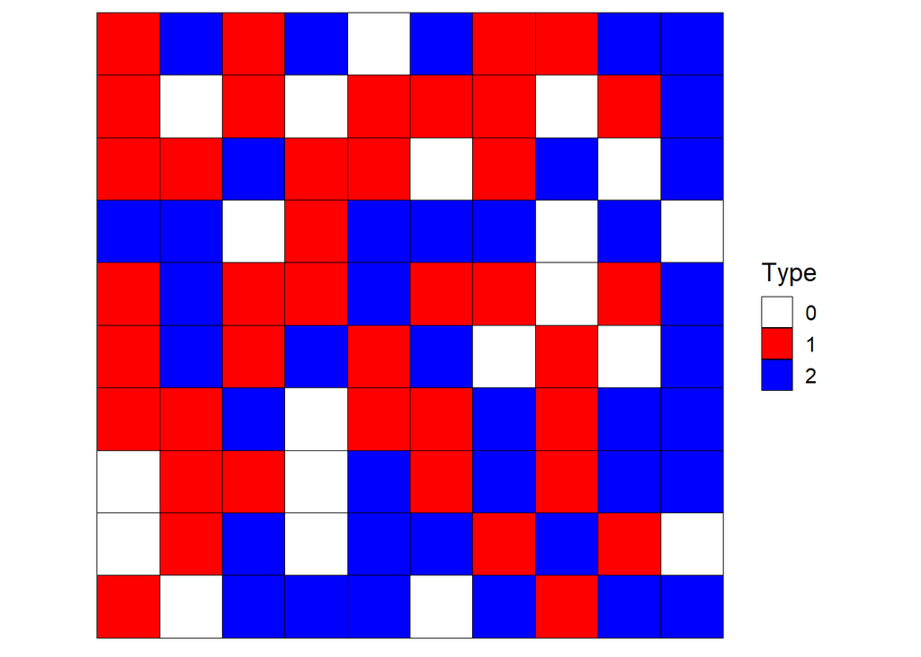

Figure 2: A newly generated world with with two types of population.

```r
plot_world(world)
```

You should see a grid where agents from two different groups are randomly placed, alongside empty spaces. This visualization helps us **verify that the setup matches our expectations**—an important habit when building agent-based models.

## Defining the Sequence

Now that we can generate and visualize a single world, it’s time to define a **time step** and the overall **dynamics of a sequence** —that is, how agents decide to move and when the simulation stops.

First, we always need to define when a sequences should **stop**. A reasonable approach in our specific case is to end the simulation if either:

- **All agents are happy**, or
- We’ve reached a predefined **maximum number of time steps**, `max_t`.

This is something **you as the modeler** have to define. There’s no single *correct* rule—**it depends on your assumptions and goals**. In the Schelling model, an agent’s happiness depends solely on the **types of its neighbors**. Each agent inspects its surrounding neighbors and compares how many of them are of the **same type**. To formalize this, we introduce a parameter called `happiness_threshold`, denoted $h_t$:

- If the **fraction of neighbors of the same type** is **below** this threshold, the agent is unhappy.
- Otherwise, the agent is considered happy.

This rule introduces **individual evaluation** based on local surroundings—one of the core ideas behind agent-based models. It also means that small changes in $h_t$ can lead to very different global outcomes, a feature we’ll explore later.

This gives us a snapshot of the current state—but in order to simulate **change**, we also need to define how agents act when they’re unhappy. At each time step, **unhappy agents** will move to a **random empty vertex** in the grid. This introduces dynamics to the model and allows the system to evolve.

```r
model <- list(
  # --- world generation ---
  world_size   = 10,          # creates a world of 10x10 vertices
  world_empty  = 0.2,         # 20% of the grid is empty
  pop_shares   = c(0.5, 0.5), # equal population sizes for two groups
  seed         = 42,          #
  # --- sequences ---
  happiness_threshold = 0.5,  # A agent is happy if at least 50% of vertices have the same color
  max_t   = 250               # Stop the sequences after 250 steps
)
```

Before we can write the `run_step()` and `run_sequence()` function, we’ll need a helper function `get_unhappy_agents()`, that scans the population and returns the **indices** of all unhappy agents.

```r
# Find all unhappy agents and return their indices
get_unhappy_agents <- function(world, model) {
  # 1) Pull out the per-vertex types (0 = empty, 1..k = agent types)
  types <- V(world)$type

  # 2) Get the list of neighbors for each vertex
  nbrs <- adjacent_vertices(world, V(world))

  # 3) Threshold
  h_t <- model$happiness_threshold

  # 4) For each agent, compute if unhappy
  is_unhappy <- vapply(
    seq_along(types),
    FUN = function(i) {
      t_i <- types[i]
      if (t_i == 0) return(FALSE)    # skip empty

      neigh_vs <- nbrs[[i]]
      # get only occupied neighbors
      occ_neigh <- neigh_vs[types[neigh_vs] > 0]
      if (length(occ_neigh) == 0) return(FALSE)  # no neighbors → happy

      same_type <- sum(types[occ_neigh] == t_i)
      frac_same <- same_type / length(occ_neigh)
      frac_same < h_t
    },
    FALSE
  )

  # 5) return the indices of unhappy agents
  which(is_unhappy)
}
```

### One Time Step

Now we define how one step in the simulation works. The `run_step()` function does the following:

1. **Identifies unhappy agents** via `get_unhappy_agents()`, which returns the indices of all agents whose fraction of like‐typed neighbors falls below the model’s happiness_threshold.
2. Randomizes their move order, creating an implicit sequential update: **each agent**, in turn, **picks** one of the remaining **empty vertices at random and moves there**.
3. **Updates the empty‐vertices pool** on the fly, so no two agents can occupy the same spot in a single step.

**Important**

Note that we designed it so that later movers see the landscape changed by earlier movers. As an alternative, you could implement a synchronous update: have all unhappy agents propose a destination simultaneously and only relocate those whose chosen vertices aren’t contested. That variant changes the model’s micro-dynamics (and potentially can affect things like convergence speed and pattern formation). So keep in mind that even such small design choices can affect the outcome of your simulation.

```r
run_step <- function(world, model) {
  # pull out types & unhappy list
  types   <- V(world)$type
  unhappy <- get_unhappy_agents(world, model)

  # nothing to do?
  if (length(unhappy) == 0) {
    return(world)
  }

  # randomize move order
  unhappy <- sample(unhappy)

  # track current empty vertices
  empties <- which(types == 0)

  # choose for each agent a random location
  for (agent in unhappy) {
    # if no empties left, bail out
    if (length(empties) == 0) break

    # choose a random empty vertice
    target <- sample(empties, 1)

    # move the agent
    types[target] <- types[agent]
    types[agent]  <- 0L

    # update empties in‐place: replace the used slot with the old agent index
    idx <- match(target, empties)
    empties[idx] <- agent
  }

  # write back and return
  V(world)$type <- types

  world
}
```

### Full Run

Now we’re ready to define the full simulation loop. The function `run_sequence()`:

```r
run_sequence <- function(model) {
  # 1) Initialization
  world <- init_world(model)

  # 2) Iterate
  for (t in seq_len(model$max_t)) {
    # if all agents are happy stop
    if (length(get_unhappy_agents(world, model)) == 0) break

    world <- run_step(world, model)
  }

  world
}
```

## Extracting Data

Now that we can run full agent-based model, it’s time to generate and analyze some **data**. After all, simulation is only useful if we can learn something from the results.

There are generally two types of insights we’re after:

1. **Final outcomes**: What does the world look like at the end of a sequences?  
   In our case, this could mean the final **segregation level**, the number of **unhappy agents**, or a snapshot of the **world layout**.
2. **Temporal dynamics**: How did the system **evolve over time**?  
   This includes tracking how **happiness** and **segregation** changed at each step.

Let’s start by defining a helper function to compute segregation. The `get_data_segregation()` function calculates, for each non-empty vertex, the **fraction of like-type neighbors**, then returns the **average** across all agents.

```r
get_data_segregation <- function(world) {
  types <- V(world)$type
  nbrs  <- adjacent_vertices(world, V(world))

  # for each occupied vertice, compute fraction of same‐type neighbors
  fracs <- vapply(seq_along(types), function(i) {
    t_i <- types[i]
    if (t_i == 0) return(NA_real_)    # skip empties

    neigh <- nbrs[[i]]
    occ   <- neigh[types[neigh] > 0]
    if (length(occ) == 0) return(1)    # isolated → perfect “self‐sorting”

    sum(types[occ] == t_i) / length(occ)
  }, numeric(1))

  mean(fracs, na.rm = TRUE)
}
```

This gives us a **segregation score** between 0 and 1, where:

- `1` means agents are only surrounded by their own type (full segregation),
- `0` means total mixing (no two agents of the same type are neighbors).

Next, we extend our `run_sequence()` function to **record time series data** during the simulation:

- `unhappy_series` tracks the proportion of unhappy agents at each time step.
- `segregation_series` tracks the average segregation level.

```r
run_sequence <- function(model,
                      verbose   = FALSE  # print progress?
                      ) {
  # 1) Initialization
  world <- init_world(model)

  # 2) prepare data storage
  unhappy_series     <- integer(0)
  segregation_series <- numeric(0)


  # 3) Iterate
  for (t in seq_len(model$max_t)) {
    unhappy <- get_unhappy_agents(world, model)
    unhappy_series[t] <- length(unhappy) / length(which(V(world)$type != 0))

    segregation_series[t] <- get_data_segregation(world)

    # print the results step by step if wanted
    if (verbose) {
      message(sprintf(
        "Step %3d: unhappiness = %3.0f, segregation = %.3f",
        t, unhappy_series[t], segregation_series[t]
      ))
    }

    # stop if equilibrium reached
    if (unhappy_series[t] == 0) {
      if (verbose) message("All agents are happy. Stopping.")
      break
    }

    # otherwise perform one step
    world <- run_step(world, model)
  }

  # 4) Return final state and summary
  list(
    final_world        = world,
    unhappy_series     = unhappy_series,
    segregation_series = segregation_series,
    steps_taken        = t,
    converged          = unhappy_series[t] == 0
  )
}
```

Let’s now run our first full ABM:

```r
results <- run_sequence(model)
```

Here’s how the final world looks after the simulation reaches equilibrium:

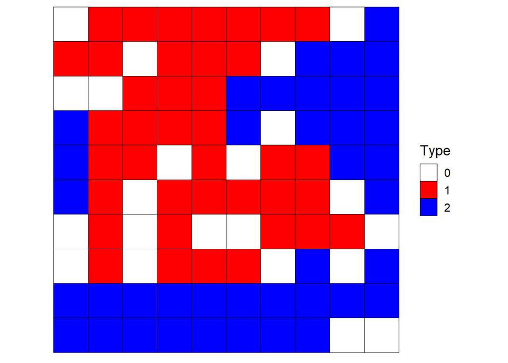

Figure 3: Final world of our Schelling Model.

```r
plot_world(results$final_world)
```

To understand how the system evolved, we plot both **unhappiness** and **segregation** over time:

**Show R Code (Time-series graph)**

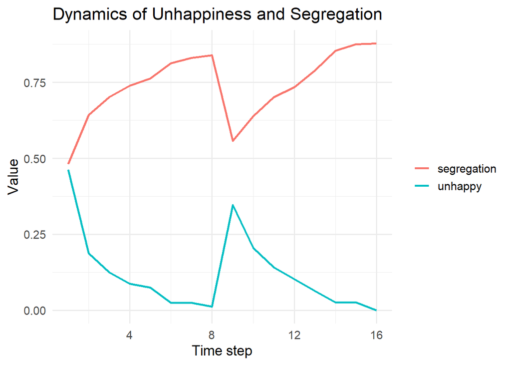

Figure 4: The development of unhappyness and segration over the course of time.

```r
steps <- seq_along(results$unhappy_series)

df <- data.frame(
  step       = steps,
  unhappy    = results$unhappy_series,
  segregation= results$segregation_series
)

# pivot to long format
df_long <- pivot_longer(
  df,
  cols        = c("unhappy", "segregation"),
  names_to    = "metric",
  values_to   = "value"
)

# plot
ggplot(df_long, aes(x = step, y = value, color = metric)) +
  geom_line(size = 1) +
  labs(
    x     = "Time step",
    y     = "Value",
    color = NULL,
    title = "Dynamics of Unhappiness and Segregation"
  ) +
  theme_minimal(base_size = 14)
```

Now we have a **complete agent-based model**! It generates a world, simulates agents interacting over time, and produces useful data like segregation and unhappiness. But it doesn’t really tell us much on its own. Why? Because everything is currently fixed:

- We’re using **a single parameter set** (`model`).
- We’re using **a fixed seed** for reproducibility. This is a great start, but it can lead us to false confidence. Maybe the results we saw were due to a lucky coincidence—or unlucky noise!

Hence, to really understand what’s going on, we need to **set up multiple sequences** and **explore the parameter space**. This is what we will do next.

# 🎛️ Full Simulation

A **simulation**, in the broader sense, means **systematically varying models and repeating them many times** to average out randomness. As illustrated in Figure 5, a complete simulation includes:

- **Multiple model variants** (e.g., different values for `happiness_threshold`).
- **Multiple replications** of each variant to estimate variability and robustness.

All results from all sequences are then **aggregated** to identify trends and generate robust insights.

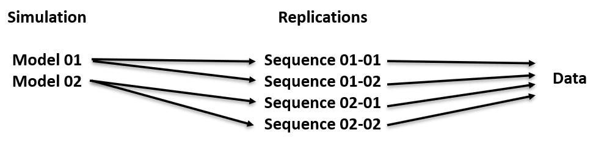

Figure 5: A complete simulation consists of several models that are replicated several time.

## Replications

Let’s start with **replicating one model** multiple times. We define a `run_replications()` function that:

- Takes a model and the number of replications $r$.
- Runs the **sequence** $r$ times, each time using a **different reproducible seed** (using a `master_seed`).
- Collects data across each replication.
- Computes **averages** and **standard deviations** of segregation and unhappiness over time.

```r
run_replications <- function(model,
                             replications = 10,
                             master_seed  = 42
                            ) {

  # 1) prepare a `results` vector
  results <- vector("list", replications)

  # 2) run the replications
  for (r in seq_len(replications)) {
    model$seed <- master_seed + r
    results[[r]] <- run_sequence(model)
  }

  # Extract series and align by length
  max_steps <- max(sapply(results, function(x) length(x$unhappy_series)))

  # Helper to fill with the last value if run ended early
  fill_with_last <- function(series, len) {
      c(series, rep(tail(series, 1), len - length(series)))
  }

  # Generate data matrices
  unhappy_mat <- matrix(sapply(results, function(x) fill_with_last(x$unhappy_series, max_steps)), nrow = max_steps)
  segreg_mat <- matrix(sapply(results, function(x) fill_with_last(x$segregation_series, max_steps)), nrow = max_steps)

  # 3) calculate mean and sd at each time step
  df_sequence <- data.frame(
    step             = seq_len(max_steps),
    unhappy_mean     = apply(unhappy_mat, 1, mean, na.rm = TRUE),
    unhappy_sd       = apply(unhappy_mat, 1, sd  , na.rm = TRUE),
    segregation_mean = apply(segreg_mat , 1, mean, na.rm = TRUE),
    segregation_sd   = apply(segreg_mat , 1, sd  , na.rm = TRUE)
  )

  # 4) calculate the final values for each replication
  df_final <- data.frame(
    replication       = seq_len(length(results)),
    converged         = sapply(results, `[[`, "converged"),
    steps_taken       = sapply(results, `[[`, "steps_taken"),
    final_segregation = sapply(results, function(x) tail(x$segregation_series, 1)),
    final_unhappy     = sapply(results, function(x) tail(x$unhappy_series,     1))
  )

  # 5) return results
  list(
    df_sequence = df_sequence,
    df_final    = df_final
  )
}
```

**Note**

The `run_replications()` function returns **two data frames**:

- `df_sequence`:  
  This contains the **aggregated dynamics over time** — the **mean** and **standard deviation** of unhappiness and segregation at each time step.
- `df_final`:  
  This contains the **final outcomes** for each individual sequence — such as whether the system **converged**, how many **steps were taken**, and the **final segregation** and **unhappiness levels**.

Depending on your project or analysis needs, you might want to add, drop, or extend these variables. In general it is a **good idea to write a helper function** like `get_data_sequence()` to make your code easier to read.

Now, we can easily simulate **many sequences** of the same model and see what happens **on average**:

```r
results <- run_replications(model, replications = 100)
```

Let’s plot the aggregated dynamics with uncertainty bands to show variability across the replications:

**Show R Code (Summary plot)**

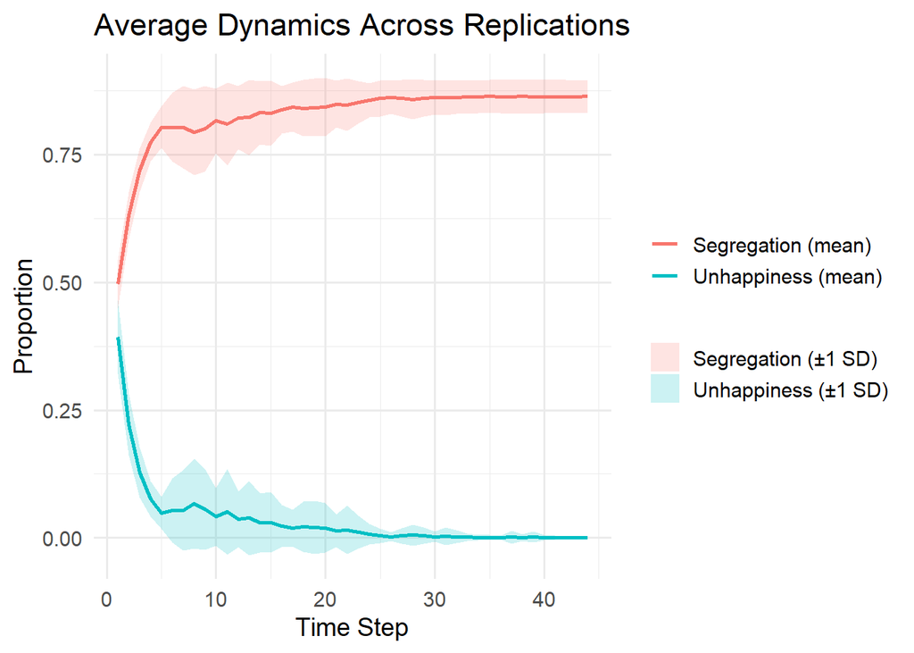

Figure 6: Average dynamics across 100 replications, with ±1 SD shown as shaded bands.

```r
ggplot(results$df_sequence, aes(x = step)) +
  geom_line(aes(y = unhappy_mean, color = "Unhappiness (mean)"), size = 1) +
  geom_ribbon(aes(ymin = unhappy_mean - unhappy_sd, ymax = unhappy_mean + unhappy_sd,
                  fill = "Unhappiness (±1 SD)"), alpha = 0.2) +
  geom_line(aes(y = segregation_mean, color = "Segregation (mean)"), size = 1) +
  geom_ribbon(aes(ymin = segregation_mean - segregation_sd, ymax = segregation_mean + segregation_sd,
                  fill = "Segregation (±1 SD)"), alpha = 0.2) +
  labs(
    title = "Average Dynamics Across Replications",
    x = "Time Step",
    y = "Proportion",
    color = NULL,
    fill = NULL
  ) +
  theme_minimal(base_size = 14)
```

We can even turn this into a **formal hypothesis**:

Of course, this only tells us that convergence happens and how fast it happens under our baseline parameters. What it doesn’t tell us is why or which factors—neighborhood radius, vacancy rate, population balance, tolerance threshold—drive that behavior. That’s the true power of ABMs: by systematically varying individual parameters, we can uncover the mechanisms at play and generate targeted hypotheses about each one.

## Simulation

In order to move from simple replications to a **full simulation study**, we need to **systematically vary** some of the parameters in our model. The goal is to:

- Define a **family of models** (by changing one or more parameters),
- Replicate each of these models multiple times,
- **Combine** all the resulting data into organized datasets.

To manage this cleanly, we introduce a new object: the `simulation` list. It works similarly to a `model` but contains **all the meta-information** we need for a full simulation. For now, it will contain **four variables**:

- The **name** of the model we are using,
- The **number of replications** for each variant,
- The **master seed** for reproducibility,
- A detailed **instruction table** (`tbl_parameter`) describing which parameters of the model should vary and **how**.

Here is a minimal example:

```r
simulation  <- list(
  model = "baseline",
  replications = 10,
  master_seed  = 42,
  tbl_parameter = expand.grid(
    happiness_threshold = seq(0, .8, length.out = 5)
  )
)
```

While `replications` and `master_seed` should be straightforward, the fields `model` and `tbl_parameter` require a bit more explanation.

### Storing and Loading Models

In theory, every researcher carefully documents the exact models they run. In practice, however, working with agent-based models often feels more chaotic. You tweak a parameter here, modify a rule there, and before long, it becomes very difficult to remember exactly which model produced which set of results. Without a clear structure, it is easy to lose track of how different simulations relate to different model assumptions.

To avoid this problem, it is a good idea to introduce a **systematic infrastructure** for managing models. Our goal is simple: we want to have a clear and consistent way of **labeling** and **storing** the data we create. This will allow us to organize our work, trace results back to specific model versions, and maintain reproducibility as we experiment and explore.

Instead of having models scattered across different scripts, we will create a centralized **model repository**: a simple function where all our models are stored by name. To interact with this repository, we define a helper functions to **load** an existing model by its name.

Here is how we can set up this infrastructure:

```r
# functions_models.R
load_model <- function(model_name) {

  # define a baseline model
  baseline <- list(
    # --- world generation ---
    world_size   = 10,          # creates a world of 10x10 vertices
    world_empty  = 0.2,         # 20% of the grid is empty
    pop_shares   = c(0.5, 0.5), # equal population sizes for two groups
    seed         = 42,          #
    # --- run ---
    happiness_threshold = 0.5,  # A agent is happy if at least 50% of vertices have the same color
    max_t   = 250               # Stop the run after 250 steps
  )

  # Modify the baseline model
  # Note that in here no commas a needed between the parameters
  baseline_big <- within(baseline, {
    world_size       = 100
  })

  if (exists(model_name, inherits = FALSE)) {
    # fetch the model
    model <- get(model_name)
    # add a name
    model$name = model_name
    # return
    model
  } else {
    stop("Error: Model name not found.")
  }
}
```

In the example above, the model repository contains two models: `baseline` and `baseline_big`. The model `baseline_big` is not created from scratch; instead, it is based on the information stored in `baseline`, with specific parts modified afterward. This is a very convenient and powerful approach: it allows us to easily define variations of a base model without duplicating the entire structure.

However, it is important to be aware of one consequence: if you later modify the original `baseline` model, those changes will automatically propagate to `baseline_big` if it depends on it. Typically, I store this model management infrastructure in a **separate R script file**. This keeps the main modeling code clean and uncluttered, and makes it easier to maintain a tidy workflow as your set of models grows.

Note, that for each model the parameter `name` is added, we will use this `name` when generating and storing data. This way you always know with which model these data was created. Later on, we simply call:

```r
model <- load_model("baseline")
```

In addition to clarity, this setup offers several important benefits for our simulation workflow. First, it **improves traceability**: for every dataset we generate, we know exactly which model parameters were used. Second, it **increases flexibility**: we can easily create multiple model versions and switch between them without cluttering the code. Third, it **strengthens reproducibility**: if someone asks how a certain result was produced, we can retrieve the model definition directly from the model repository.

Good modeling practice is not only about building sophisticated simulations, but also about building simulations that you and others can understand and reproduce later on.

In the next step, we will leverage this infrastructure to systematically vary parameters, generate multiple model variants, and conduct full simulation experiments based on a tidy, organized pipeline.

### Modifying Models

Now that we have established a clean infrastructure for storing and loading models, let us turn to the next key component of a simulation study: **systematically varying parameters**. This task is managed by the `tbl_parameter` object inside our `simulation` list. The `tbl_parameter` can be thought of as a 2-dimensional matrix (or more precisely, a data frame) that stores all combinations of parameters we want to test. Each row of this table corresponds to a different variant of the base model.

For now, we are content with varying just one parameter, so `tbl_parameter` will be a simple vector:

```
  tbl_parameter = expand.grid(
    happiness_threshold = seq(0, .8, length.out = 5)
  )
```

This specifies that we will systematically vary the `happiness_threshold` parameter, using five evenly spaced values between 0 and 0.8. Each value will represent a different “version” of the model to be simulated and analyzed.

Now that we can define a grid of parameters, all we need is a function that systematically runs all these model variants, replicates each variant multiple times, and collects the results in a structured way.

Here is how we can build such a function, which we will call `run_simulation()`:

```r
run_simulation <- function(simulation){
  # 1) load the baseline model
  model <- load_model(simulation$model)

  # 2) prepare a list to collect each model’s result
  results <- vector("list", length = nrow(simulation$tbl_parameter))

  # 3) run all replications for all models
  for (i in seq_len(nrow(simulation$tbl_parameter))) {
    # fetch the temporary parameters
    tmp_parameter <- simulation$tbl_parameter |>
      slice(i) |>
      as.list()

    # replace the baseline model parameters with the temporary parameters
    tmp_model <- modifyList(model, tmp_parameter)

    # run the replications with this temorary model
    result <- run_replications(model        = tmp_model,
                               replications = simulation$replications,
                               master_seed  = simulation$master_seed)

    # now we add the model name and the parameters that are changed
    # this function add it to df_process and df_final
     results[[i]] <- result %>%
       map(~ .x %>%
         mutate(
              model = tmp_model$name,
              !!!tmp_parameter
            )
         )
  }

  # 4) bind all df_process together, and all df_final together
  all_df_sequence <- map(results, "df_sequence") %>%
    bind_rows()

  all_df_final   <- map(results, "df_final") %>%
    bind_rows()

  # 5) return as a list of two data frames
  list(
    df_sequence = all_df_sequence,
    df_final   = all_df_final
  )
}
```

Finally, we can launch our full simulation study by simply calling:

```r
results <- run_simulation(simulation)
```

## Analyzing the Simulation Results

Now that we have run our full simulation experiment, we can begin analyzing how changes in the `happiness_threshold` affect the system’s final outcomes.  
Specifically, we are interested in two questions:

- How does the happiness threshold influence the **final proportion of happy agents**?
- How does the happiness threshold influence the **final level of segregation**?

We can visualize these relationships by plotting the relevant variables from our collected `df_final` dataset.

**Show R Code (Plot)**

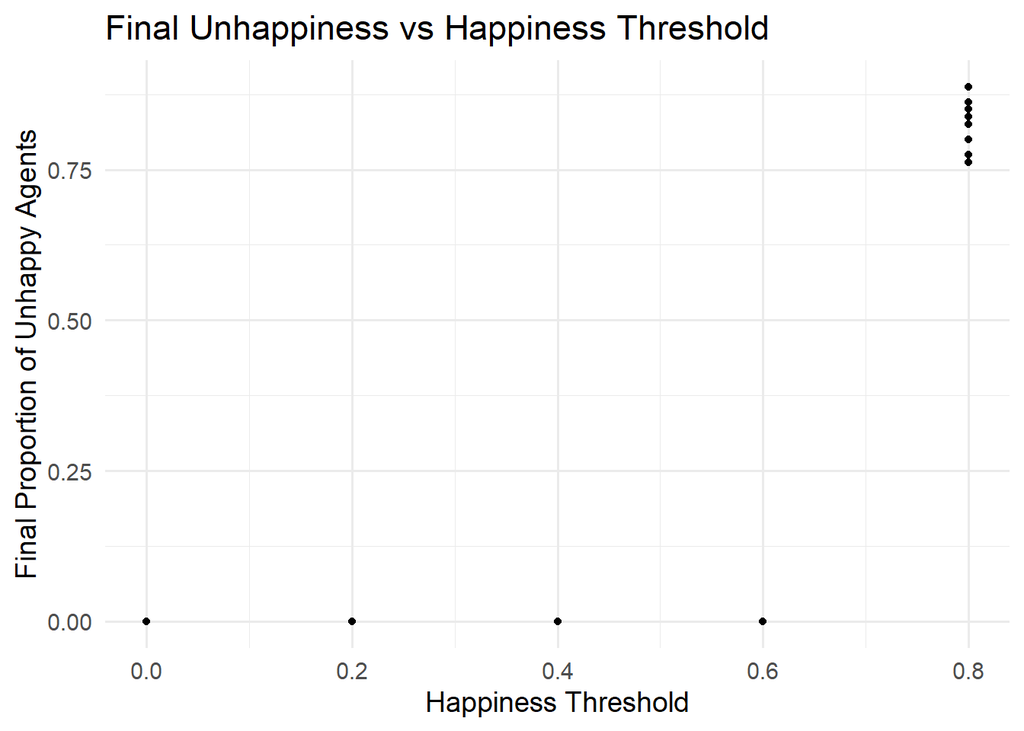

Figure 7: Final Unhappiness vs Happiness Threshold.

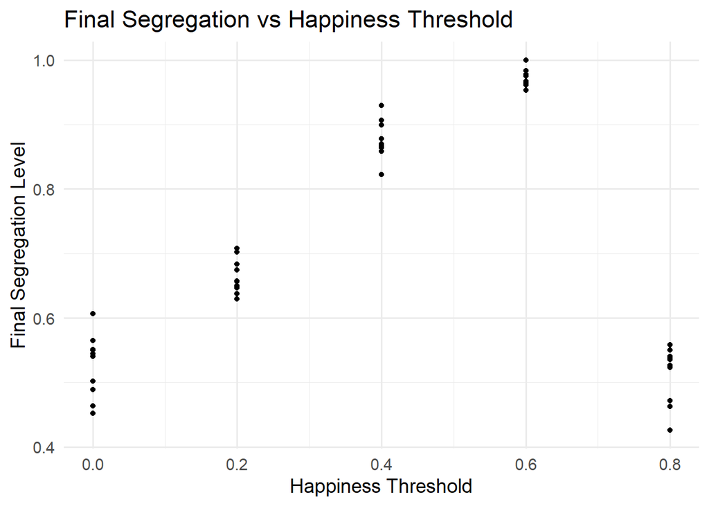

Figure 8: Final Segregation vs Happiness Threshold.

```r
ggplot(results$df_final, aes(x = happiness_threshold, y = final_unhappy)) +
  geom_point() +
  labs(
    title = "Final Unhappiness vs Happiness Threshold",
    x = "Happiness Threshold",
    y = "Final Proportion of Unhappy Agents"
  ) +
  theme_minimal(base_size = 14)

ggplot(results$df_final, aes(x = happiness_threshold, y = final_segregation)) +
  geom_point() +
  labs(
    title = "Final Segregation vs Happiness Threshold",
    x = "Happiness Threshold",
    y = "Final Segregation Level"
  ) +
  theme_minimal(base_size = 14)
```

These two plots provide our first detailed visual impression of how the happiness threshold influences the emergent macro-level outcomes of the system.

To better capture these nonlinear relationships, we can estimate **regression models** that allow for transformations of the predictor variables.

For the relationship between happiness threshold and unhappiness, we will include a **logarithmic transformation** of the happiness threshold.  
For the relationship between happiness threshold and segregation, we will include a **quadratic term** (i.e., the square of the happiness threshold).

Here is how we can specify and estimate these models:

**Show R Code (Advanced Regression)**

```r
# Load packages
library(broom)
library(modelsummary)

# Create new variables for transformations
results$df_final <- results$df_final %>%
  mutate(
    log_happiness_threshold = log(happiness_threshold + 0.01),  # add small constant to avoid log(0)
    happiness_threshold_sq  = happiness_threshold^2
  )

# Model 1: Log-transformed predictor for unhappiness
model_log_happy <- lm(final_unhappy ~ log_happiness_threshold, data = results$df_final)

# Model 2: Quadratic model for segregation
model_quad_segreg <- lm(final_segregation ~ happiness_threshold + happiness_threshold_sq, data = results$df_final)

# Create a regression table with significance stars
modelsummary(
  list(
    "Unhappiness (log model)" = model_log_happy,
    "Segregation (quadratic model)" = model_quad_segreg
  ),
  statistic = "({std.error})",
  stars = TRUE,            # <- Add stars based on p-values
  gof_omit = "IC|Log|Adj",  # optional: omit information criteria if you want a cleaner table
  output = "markdown"
)
```

Table 1: Regression results allowing for nonlinear effects.

|  | Unhappiness (log model) | Segregation (quadratic model) |
| --- | --- | --- |
| (Intercept) | 0.299*** | 0.466*** |
|  | (0.060) | (0.030) |
| log_happiness_threshold | 0.087** |  |
|  | (0.027) |  |
| happiness_threshold |  | 2.029*** |
|  |  | (0.176) |
| happiness_threshold_sq |  | -2.358*** |
|  |  | (0.211) |
| Num.Obs. | 50 | 50 |
| R2 | 0.177 | 0.739 |
| F | 10.325 | 66.575 |
| RMSE | 0.30 | 0.10 |

+ p < 0.1, * p < 0.05, ** p < 0.01, *** p < 0.001

Thus, by combining simulation experiments, data visualization, and flexible regression modeling, we are able to uncover subtle but important dynamics in the behavior of our agent-based system.

# 📋 Reporting the ABM

While writing an agent-based model (ABM) can be a lot of fun, it’s only one part of the work. Just as important is clearly **communicating the purpose of your ABM,** how it operates, and why it was built. The most widely used method for reporting an ABM is the **ODD protocol**, which stands for “Overview, Design concepts, Details.” Introduced by Grimm et al. (2006) and updated in (2020), ODD provides a structured approach to describing models. A comprehensive overview of the protocol is available on the [website of the Network for Computational Modeling in Social and Ecological Sciences (CoMSES)](https://www.comses.net/resources/standards/).

The **main goal of ODD** is to make scientists’ lives easier—both by guiding modelers through the conceptualization process and by facilitating the reproduction and validation of models. Standardized reporting also helps readers better understand each component of a model. The key components of the ODD protocol are:

1. Purpose and patterns
2. Entities, state variables, and scales
3. Process overview and scheduling
4. Design concepts
5. Initialization
6. Input data
7. Submodels

Below we go step-by-step through each component to thoroughly document the Schelling segregation model. A more complex example can be found at [Felix Lennert’s website](https://bookdown.org/f_lennert/book-toolbox_css/agent-based-modeling.html#how-to-report-abms-the-odd-protocol).

### Purpose and patterns

**Goal:** Clearly state the primary purpose of your model and specify the patterns it aims to reproduce or explore.

Edmonds et al. (2019) identified seven general, or high-level, **purposes** for building a model. While elements of several purposes may be present in your work, it is often advisable to commit to one primary purpose. Doing so will help you stay focused during model development. The seven general purposes are:

- **Prediction:** Building a model to reliably anticipate specific aspects of unknown data with useful accuracy, based on computations using the model.
- **Explanation:** Using the model to establish possible causal chains—showing how a certain setup leads to particular outcomes through underlying mechanisms.
- **Description:** Representing important features of a specific observed case (or a small set of related cases) in a partial but meaningful way.
- **Theoretical Exposition:** Developing and testing hypotheses about the general behavior of a set of mechanisms by simulating them and analyzing the outcomes.
- **Illustration:** Communicating or clarifying an idea, theory, or explanation by showing how it plays out within a model.
- **Analogy:** Using the processes in a simulation as a way of thinking informally about real-world phenomena.
- **Social Learning:** Using the ABM as a tool to facilitate shared understanding and help others explore and internalize the concepts and ideas represented in the model.

**Patterns** are observations—at either the individual or system level—that are thought to be driven by the key processes, variables, or mechanisms relevant to your model’s purpose. In some cases, the goal of a simulation is to successfully reproduce these patterns; in others, demonstrating the model’s inability to replicate certain patterns may itself serve as a meaningful result.

In the case of the Schelling segregation model, the primary purpose is to **illustrate** the relationship between individual-level rules (tolerance for diversity) and **macro-level patterns** (segregation). A secondary purpose is to use the model as a **social learning** tool for teaching students how to develop and understand agent-based models.

### Entities, state variables, and scales

**Goal:** Identify and describe the different entities (agents, environment), their attributes, and the temporal/spatial scales of the model.

**Entities** refer to all the **distinct components** that make up the model. These typically include individuals, collectives, their environment, and any structures they interact with, such as networks or grids.

For each type of entity, you should describe its **state variables** (also called “**attributes**”). State variables are characteristics that can either change over time (such as an agent’s position) or remain constant but vary across entities (such as an agent’s type). It is important to distinguish between state variables and parameters: **parameters** are variables that are the same across all entities and do not vary individually. For example, in the Schelling segregation model, the happiness threshold is a parameter if it is identical for every agent. However, if we assign each agent a different happiness threshold by randomly drawing values from a distribution, then the threshold becomes an individual state variable. In that case, the parameters of the distribution itself (such as its mean and variance) would become the model’s parameters.

Finally, the model’s **scales** refer to two aspects of spatial and temporal structure of the model: the **extent**—the total amount of space and time the model covers—and the **resolution**—the size of spatial units and the length of time steps. In many non-illustrative models is essential to clarify what these units represent in the real world.

For example, in the Schelling segregation model, there are two entities: agents and the grid. Agents are characterized by their type (indicating group affiliation) and their position on the grid. The grid itself is a square lattice of cells, each of which can either be occupied by an agent or remain empty. The model operates in discrete time steps, with up to 250 steps on a 10×10 grid. Since the model’s primary purpose is illustrative, neither the temporal nor spatial scales need to be highly precise. Roughly, one time step could represent between one month and one quarter of a year, and each cell of the grid can be thought of as representing a house.

### Process overview and scheduling

**Goal:** Describe the sequence of events in one simulation step clearly, specifying the order and scheduling of agent actions and processes. Here is a great place for a flow chart.

At each discrete time step each agent assesses the proportion of neighbors who share its type. Agents become unhappy if the proportion of similar neighbors is below their happiness threshold. Unhappy agents sequentially move in a random order to random empty cells. The simulation continues iterating these steps until either all agents are happy or a maximum number of steps is reached.

### Design concepts

**Goal:** In this section, relate your model to eleven common design concepts in agent-based modeling (ABM). Grimm et al. (2020) developed a list of **11 design concepts** that should be addressed when describing an ABM. Note that not all models make use of every concept. For any concept that is not relevant, simply state clearly that it is not implemented or included.

Below are the design concepts you should address:

- **Basic Principles:** Describe the general theories, hypotheses, or modeling approaches that underlie your model’s design, both at the system and agent levels. How does your model relate to existing approaches? How are these theories implemented? Does it incorporate new ideas or literature that have not yet been modeled?
- **Emergence:** Identify which model outcomes arise from agent interactions or system dynamics, and which outcomes are directly imposed by model rules. Explain why some results may be considered more or less emergent.
- **Adaptation:** Specify how agents make decisions in response to stimuli. What alternatives can they choose from? Which variables influence their decisions, and are agents directly or indirectly seeking to optimize objectives?
- **Objectives:** Define the key goals that agents are trying to achieve. What objective measures are used to assess success? How are these measures calculated, and what is the rationale behind them?
- **Learning:** Indicate whether agents adjust their decision-making based on prior experience. If so, describe how this learning process is implemented.
- **Prediction:** Explain whether agents attempt to foresee future outcomes and adjust their behavior accordingly. If they do, describe the prediction mechanism.
- **Sensing:** Detail whether agents can perceive the state variables of other entities. Typically, full information is assumed, but if the sensing process is imperfect, explain how it is modeled.
- **Interactions:** Describe how agents interact—whether interactions are direct (e.g., communication) or mediated (e.g., through a shared environment).
- **Stochasticity:** Identify where and how randomness is incorporated into the model. Describe any stochastic processes affecting decisions, events, or outcomes.
- **Collectives:** Specify whether agents form groups or collectives that influence and are influenced by individual agents. If so, explain how these collectives function and what effects they have.
- **Observation:** Describe the main outputs of the model that are used for analysis. Explain how these outputs are generated and recorded during simulations.

And now for our Schelling model:

- **Basic Principles:** The Schelling segregation model is based on Schelling’s (1971) original hypothesis that even mild preferences for neighbors of the same type can lead to significant segregation. This model does not incorporate new theoretical approaches but clearly demonstrates this fundamental insight.
- **Emergence:** Segregation patterns emerge from individual agents following simple rules based on their local neighborhood composition. The segregation outcome is not directly imposed but emerges naturally through interactions.
- **Adaptation:** Agents adapt by relocating if their neighborhood composition does not satisfy their threshold for happiness. They choose from available empty cells randomly.
- **Objectives:** Agents aim to reside in neighborhoods where a certain minimum proportion of neighbors are similar to themselves. This is quantified by the happiness threshold.
- **Learning:** Learning is not implemented; agents do not adjust their behavior based on past experiences.
- **Prediction:** Prediction is not implemented; agents do not foresee or anticipate future states.
- **Sensing:** Agents have complete and perfect knowledge of their immediate neighbors’ types (1 step away).
- **Interactions:** Agent interactions are mediated through the shared environment, specifically neighborhood occupancy.
- **Stochasticity:** Randomness is incorporated in initial agent placement, relocation decisions, and the sequential order in which unhappy agents move.
- **Collectives:** Collectives are not implemented; agents act individually based on their local conditions.
- **Observation:** Key outputs include measures of segregation and unhappiness, recorded at each time step for analysis.

### Initialization

**Goal:** Clearly document the initial setup of the model including how agent positions, attributes, and environmental settings are determined.

Initially, agents are randomly placed on the grid according to predefined parameters: the total population density, the proportion of each type of agent, and the proportion of empty cells. A random seed ensures reproducibility. The baseline model uses a 10x10 grid with 20% empty cells and two groups of agents equally distributed.

### Input data

**Goal:** Clearly specify any external data or parameters used to drive the model.

This model does not rely on external input data.

### Submodels

**Goal:** Provide detailed descriptions of the individual processes outlined in the model’s schedule, explaining each step and its associated submodels thoroughly. A complete description should include the equations, algorithms, parameters, and parameter values used. Additionally, justify the design decisions made for each submodel, explaining why certain approaches or assumptions were chosen. Where relevant, include robustness checks that account for different scenarios or variations the submodels might encounter.

In this simulation setup, the world is a 10×10 grid (`world_size = 10`) where 20% of the cells are initially left empty (`world_empty = 0.2`). The two groups of agents are equally sized, each comprising 50% of the non-empty cells (`pop_shares = c(0.5, 0.5)`). The key behavioral parameter is the `happiness_threshold`, which determines when an agent is considered happy: an agent is satisfied if at least `happiness_threshold` of its neighboring cells are occupied by agents of the same group. The simulation is set to run for a maximum of 250 time steps (`max_t = 250`).

For experimentation, the simulation is configured to explore how varying the `happiness_threshold` affects the outcomes of segreation. Specifically, the `happiness_threshold` parameter is systematically varied across five equally spaced values between 0 and 0.8. Each configuration is replicated 10 times to account for stochastic effects.

**Happiness evaluation:** Each agent calculates the fraction of neighboring cells occupied by similar-type agents. Empty cells are ignored. If this fraction is below the defined threshold, the agent is unhappy.
$$\frac{\sum \text{same-type agents in neighborhood}}{\sum \text{all agents in neighborhood}}$$

```
# function used to determine wheter agent i is unhappy (= TRUE) or not (=FALSE)
function(i) {
      t_i <- types[i]                             # get i's type
      if (t_i == 0) return(FALSE)                 # skip empty

      neigh_vs <- nbr[[i]]                        # get i's neighbors
      occ_neigh <- neigh_vs[types[neigh_vs] > 0]  # keep only occupied neighbors
      if (length(occ_neigh) == 0) return(FALSE)   # no neighbors → happy

      same_type <- sum(types[occ_neigh] == t_i)   # get # same-type neighbors
      frac_same <- same_type / length(occ_neigh)  # calc share
      frac_same < h_t                             # check against happiness treshold (h_t)
    }
```

**Agent movement:** Unhappy agents relocate to a randomly chosen empty cell. The order of movement is randomized each time step, ensuring fair and unbiased agent relocation.

```
  # randomize move order of unhappy agents
  unhappy <- sample(unhappy)

  # track current empty vertices
  empties <- which(types == 0)

  # choose for each agent a random location
  for (agent in unhappy) {
    # if no empties left, bail out
    if (length(empties) == 0) break

    # choose a random empty vertice
    target <- sample(empties, 1)

    # move the agent
    types[target] <- types[agent]
    types[agent]  <- 0L

    # update empties in‐place: replace the used slot with the old agent index
    idx <- match(target, empties)
    empties[idx] <- agent
  }
```

**Robustness checks** : No robustness checks were made.

# 🧩 Conclusion

In this chapter, we have learned how from building a basic agent-based model to executing a full simulation. We started with the essential building blocks of ABMs: defining a model, specifying a world, and implementing simple time step rules. From there, we learned how to structure model replication and systematically vary parameters to uncover deeper system behaviors.

Along the way, we emphasized good scientific practice: ensuring reproducibility and keeping our models modular and well-organized. We saw how even small changes in agent-level rules — such as adjusting a happiness threshold — can produce large, nonlinear effects at the system level. Through systematic variation and statistical analysis, we moved beyond anecdotal simulation runs toward developing robust, reproducible insights.

This careful progression — from building simple models to running full experiments — mirrors the real research process in computational social science, ecology, economics, and many other fields. Agent-based models allow us to explore “what-if” scenarios, generate hypotheses, and understand the often surprising ways in which individual behaviors aggregate into complex patterns.

While our examples here focused on a classic model of segregation, the tools and principles you have learned are broadly applicable to many other questions and systems.

**Note**

You can [download the complete code here](https://github.com/SGrehl/SGrehl.github.io/tree/main/data/abm-segregation).

# 🏋 Pre-Class Assignment

Before the next session, take some time to engage with the model hands-on. The following exercises will help you consolidate what you’ve learned and begin thinking critically about the dynamics of agent-based models.

1. **[Easy] Run the Model Locally**  
   Download the complete example and run it on your own machine.  
   Make sure everything works and take a moment to explore the output.  
   Can you reproduce the simulation results from the chapter?
2. **[Easy] Make the Model More Flexible**  
   Modify the model to include a new parameter called `nei`, which sets the neighborhood structure when the grid network is created.  
   Try different values (e.g., 1, 2, or 3) and observe how this affects the simulation.  
   *Tip: You only need to change two lines of code — in the model definition and in the network generation function.*
3. **[Medium] Understanding the Inverted U-Shaped Curve**  
   In the simulation, we observed an inverted U-shaped relationship between the happiness threshold and final segregation levels.  
   Why might this pattern occur? Do you think it’s a general result of the model’s structure or specific to our current setup?  
   What kinds of experiments or alternative model variants could help you test the robustness of this pattern?

# 🚀 Link to In-Class Material

Here is the link for the in-class material.

# ⚙️ Some Advanced Stuff

Below are some in-depth technical notes for those who want to dive deeper into the ABM’s inner workings. Feel free to skip this section unless you’re curious about the implementation details.

## Avoid Redundancy

While the code we developed so far is clean, modular, and easy to understand, it is not the most computationally efficient version possible. This was intentional: for teaching purposes, we prioritized clarity over speed. However, if you plan to run larger-scale simulations, you will eventually want to streamline the workflow to avoid unnecessary calculations.

One major inefficiency occurs in the `run_sequence()` function. Currently, for each time step, we first calculate the number of unhappy agents to check whether the system has reached equilibrium. Then, if not all agents are happy, we execute a relocation step — and in doing so, **recalculate the exact same unhappiness value again** to record it for later analysis. Thus, we are performing the same costly neighbor inspection operation twice per step, even though once would be enough.

To fix this redundancy, we can **move** the **calculation of unhappiness** into the `run_step()` function itself. This way, we only compute these metrics once per step, immediately after the agents have moved (or chosen not to move). And while we are doing this, lets **move** the **calculation of the segregation** measure also**.**

First, we adjust the `run_step()` function so that it calculates and **stores** the unhappiness and segregation data directly inside the `world` object:

```r
# Modified run_step() function
run_step <- function(world, model) {
  # pull out types & unhappy list
  unhappy <- get_unhappy_agents(world, model)

  # calcualte data BEFORE the movement
  world$data_unhappy     <- length(unhappy) / length(which(V(world)$type != 0))
  world$data_segregation <- get_data_segregation(world)

  # are all actors happy?
  if (length(unhappy) == 0) {
    return(world = world)
  }

  # ge types
  types   <- V(world)$type
  # randomize move order
  unhappy <- sample(unhappy)
  # track current empty vertices
  empties <- which(types == 0)

  # choose for each agent a random location
  for (agent in unhappy) {
    # if no empties left, bail out
    if (length(empties) == 0) break

    # choose a random empty vertice
    target <- sample(empties, 1)

    # move the agent
    types[target] <- types[agent]
    types[agent]  <- 0L

    # update empties in‐place: replace the used slot with the old agent index
    idx <- match(target, empties)
    empties[idx] <- agent
  }

  # update all agents' types
  V(world)$type <- types

  world
}
```

Now, after every call to `run_step()`, the world already contains the updated values of unhappiness and segregation, ready to be recorded.

Next, we adjust the `run_sequence()` function to take advantage of this improvement:

```r
run_sequence <- function(model,
                      verbose   = FALSE  # print progress?
                      ) {
  # 1) Initialization
  world <- init_world(model)

  # 2) prepare data storage
  unhappy_series   <- integer(0)
  segregation_series <- numeric(0)


  # 3) Iterate
  for (t in seq_len(model$max_t)) {
    # Perform one step (and update metrics inside world)
    world <- run_step(world, model)

    # Store the data from world
    unhappy_series[t]     <- world$data_unhappy
    segregation_series[t] <- world$data_segregation

    # print the results step by step if wanted
    if (verbose) {
      message(sprintf(
        "Step %3d: unhappiness = %3.0f, segregation = %.3f",
        t, unhappy_series[t], segregation_series[t]
      ))
    }

    # stop if equilibrium reached
    if (unhappy_series[t] == 0) {
      if (verbose) message("All agents are happy. Stopping.")
      break
    }
  }

  # 4) Return final state and summary
  list(
    final_world        = world,
    unhappy_series     = unhappy_series,
    segregation_series = segregation_series,
    steps_taken        = t,
    converged          = unhappy_series[t] == 0
  )
}
```

When we choose to store data such as `data_unhappy` and `data_segregation` directly inside our `world` object, it is good practice to **initialize these variables already during world creation** — specifically inside the `init_world()` function.

There are two reasons for this. First, by initializing all expected fields in advance, we ensure that the necessary memory space is reserved, which can help avoid small inefficiencies during simulation runs. Second, and more importantly, it guarantees that **any function accessing these fields** can safely assume that they exist, even if they have not yet been updated during a run. This prevents errors or unexpected behavior when, for example, a newly initialized world is passed into an analysis function expecting `data_unhappy` and `data_segregation` to be available.

Thus, as a rule of thumb, **every field your simulation will later use should be initialized explicitly at the beginning**, even if its initial value is just `NA` or `0`. Good initialization habits make models more robust, easier to debug, and easier to extend later on.

## Further Performance with Matrices

Agent-based models often gain a big speed-up by recasting core routines as vector or matrix operations instead of iterating cell by cell. Optimized routines can make your code orders of magnitude faster than raw `for`-loops in R. That said, turning local agent rules into a few neat matrix multiplications or vectorized functions usually takes some upfront design:

- **Look for adjacency‐matrix tricks.** Can you encode neighbor counts or type comparisons as a single `%*%` or element-wise vector operation?
- **Lean on specialized packages.** Tools like **`matrixStats`**, **`data.table`**, or even **`Rcpp`** let you blend C-level speed with R-style syntax.
- **Brainstorm with an LLM.** Describe your loop logic in plain English, drop the code, and ask for a vectorized rewrite—it often spots patterns you might miss.

Of course, some parts of your simulation will inevitably require repetition—for example, kicking off hundreds of independent replications or marching time-steps sequentially. In those cases:

- **Parallelize the outer loop**. Use `parallel::mclapply()`, `future.apply`/`furrr`, or `foreach` + `doParallel` to distribute replications across multiple CPU cores. [See also my description here](https://sgrehl.github.io/general-information/sc.html#parallelization).

In short: strive for vectorized, matrix-based implementations where you can, and fall back on parallel execution when loops are truly unavoidable.

To demonstrate the performance boost, we compared two ways to multiply an two $m \times m$ matrices, once using the optimized $A \cdot B$ routine, and once a nested-loop implementation. We measured the execution time for $n=100$ (small) and $n=1000$ (big). Here are the results:

```r
library(knitr)
# Compare vectorized vs. two-loop matrix multiplication in R
# Function for vectorized multiplication

time_vectorized <- function(n) {
  A <- matrix(runif(n * n), n, n)
  B <- matrix(runif(n * n), n, n)
  start <- proc.time()["elapsed"]
  M <- A %*% B
  proc.time()["elapsed"] - start
}

# Function for loop multiplication

time_two_loops <- function(n) {
  A <- matrix(runif(n * n), n, n)
  B <- matrix(runif(n * n), n, n)
  M <- matrix(0, n, n)
  start <- proc.time()["elapsed"]
  for (i in seq_len(n)) {
    for (j in seq_len(n)) {
      M[i, j] <- sum(A[i, ] * B[, j])
      }
    }
  proc.time()["elapsed"] - start
}

sizes <- c(100, 1000)

# Run timings
results <- do.call(rbind, lapply(sizes, function(n) {
  data.frame(
    n      = n,
    method = c("Vectorized", "Two Loops"),
    time_s = c(time_vectorized(n), time_two_loops(n))
    )
}))

# Basic pipe‐table
kable(
  results,
  caption = "Performance comparison of matrix multiplication methods",
  label = "tab-matrix-multi",
  col.names = c("Matrix size (n)", "Method", "Elapsed time (s)"),
  digits   = 3
)
```

Performance comparison of matrix multiplication methods

| Matrix size (n) | Method | Elapsed time (s) |
| --- | --- | --- |
| 100 | Vectorized | 0.00 |
| 100 | Two Loops | 0.02 |
| 1000 | Vectorized | 0.58 |
| 1000 | Two Loops | 11.31 |

## References

Edmonds, Bruce, Christophe Le Page, Mike Bithell, Edmund Chattoe-Brown, Volker Grimm, Ruth Meyer, Cristina Montañola-Sales, Paul Ormerod, Hilton Root, and Flaminio Squazzoni. 2019. “Different Modelling Purposes.” *Journal of Artificial Societies and Social Simulation* 22 (3): 6. https://doi.org/10.18564/jasss.3993.

Grimm, Volker, Uta Berger, Finn Bastiansen, Sigrunn Eliassen, Vincent Ginot, Jarl Giske, John Goss-Custard, et al. 2006. “A Standard Protocol for Describing Individual-Based and Agent-Based Models.” *Ecological Modelling* 198 (1-2): 115–26. https://doi.org/10.1016/j.ecolmodel.2006.04.023.

Grimm, Volker, Steven F. Railsback, Christian E. Vincenot, Uta Berger, Cara Gallagher, Donald L. DeAngelis, Bruce Edmonds, et al. 2020. “The ODD Protocol for Describing Agent-Based and Other Simulation Models: A Second Update to Improve Clarity, Replication, and Structural Realism.” *Journal of Artificial Societies and Social Simulation* 23 (2): 7. https://doi.org/10.18564/jasss.4259.

Lindenberg, Siegwart. 1971. “Simulation Und Theoriebildung.” In, edited by Hans Albert. Meisenheim am Glan: Anton Hain.

Schelling, Thomas C. 1971. “On the Ecology of Micromotives.” *Public Interest* 25: 61–98.

Weber, Max. 1972. *Wirtschaft Und Gesellschaft*. Tübingen: Mohr Siebeck.

## Footnotes

[^1]: In the literature, this is sometimes referred to as a run. However, I prefer to avoid this term to prevent awkward phrasing such as “run a run.”

## Copyright

Copyright Sascha Grehl, 2025. All Rights Reserved